# 摩拜单车探索性数据可视化报告

## 数据集介绍

摩拜单车上海用户使用数据，摩拜单车上海城区2016年8月随机抽样百万条用户使用数据，共有102361条订单记录，包含起点、目的地、租赁时间、还车时间、用户ID、车辆ID、交易编号和路线轨迹信息

| 字段名称 | 字段含义 |
| --- | --- |
| orderid | 交易编号 |
| bikeid | 车辆ID |
| userid | 用户ID |
| start_time | 开始时间 |
| start_location_x | 开始骑行点X |
| start_location_y | 开始骑行点Y |
| end_time | 结束时间 |
| end_location_x | 结束骑行点X |
| end_location_y | 结束骑行点Y |
| track | 骑行过程中经过的地点 |

## 导入数据

```python
import numpy as np
import pandas as pd
import seaborn as sb
import matplotlib.pyplot as plt

# 设置系统中有的字体
plt.rcParams['font.sans-serif'] = ['Microsoft YaHei']
# 解决保存图像是负号'-'显示为方块的问题,或者转换负号为字符串
plt.rcParams['axes.unicode_minus'] = False

%matplotlib inline


mobike_df = pd.read_csv('mobike_shanghai_sample_updated.csv')
mobike_df.head()
```

|  | orderid | bikeid | userid | start_time | start_location_x | start_location_y | end_time | end_location_x | end_location_y | track |
| --- | --- | --- | --- | --- | --- | --- | --- | --- | --- | --- |
| 0 | 78387 | 158357 | 10080 | 2016-08-20 06:57 | 121.348 | 31.389 | 2016-08-20 07:04 | 121.357 | 31.388 | 121.347,31.392#121.348,31.389#121.349,31.390#1... |
| 1 | 891333 | 92776 | 6605 | 2016-08-29 19:09 | 121.508 | 31.279 | 2016-08-29 19:31 | 121.489 | 31.271 | 121.489,31.270#121.489,31.271#121.490,31.270#1... |
| 2 | 1106623 | 152045 | 8876 | 2016-08-13 16:17 | 121.383 | 31.254 | 2016-08-13 16:36 | 121.405 | 31.248 | 121.381,31.251#121.382,31.251#121.382,31.252#1... |
| 3 | 1389484 | 196259 | 10648 | 2016-08-23 21:34 | 121.484 | 31.320 | 2016-08-23 21:43 | 121.471 | 31.325 | 121.471,31.325#121.472,31.325#121.473,31.324#1... |
| 4 | 188537 | 78208 | 11735 | 2016-08-16 07:32 | 121.407 | 31.292 | 2016-08-16 07:41 | 121.418 | 31.288 | 121.407,31.291#121.407,31.292#121.408,31.291#1... |

## 数据评估

```python
mobike_df.describe()
```

|  | orderid | bikeid | userid | start_location_x | start_location_y | end_location_x | end_location_y |
| --- | --- | --- | --- | --- | --- | --- | --- |
| count | 1.023610e+05 | 102361.000000 | 102361.000000 | 102361.000000 | 102361.000000 | 102361.000000 | 102361.000000 |
| mean | 8.940838e+05 | 155425.868690 | 7834.435644 | 121.454144 | 31.251740 | 121.453736 | 31.252029 |
| std | 5.219651e+05 | 98816.625402 | 4530.387938 | 0.060862 | 0.057358 | 0.061577 | 0.057740 |
| min | 6.000000e+00 | 3.000000 | 1.000000 | 121.173000 | 30.842000 | 120.486000 | 30.841000 |
| 25% | 4.386790e+05 | 74701.000000 | 4095.000000 | 121.415000 | 31.212000 | 121.414000 | 31.212000 |
| 50% | 8.901510e+05 | 141990.000000 | 7617.000000 | 121.456000 | 31.260000 | 121.456000 | 31.261000 |
| 75% | 1.343252e+06 | 228303.000000 | 11278.000000 | 121.497000 | 31.294000 | 121.497000 | 31.294000 |
| max | 1.807864e+06 | 387351.000000 | 17753.000000 | 121.970000 | 31.450000 | 121.971000 | 31.477000 |

```python
mobike_df.info()
```

```
<class 'pandas.core.frame.DataFrame'>
RangeIndex: 102361 entries, 0 to 102360
Data columns (total 10 columns):
orderid             102361 non-null int64
bikeid              102361 non-null int64
userid              102361 non-null int64
start_time          102361 non-null object
start_location_x    102361 non-null float64
start_location_y    102361 non-null float64
end_time            102361 non-null object
end_location_x      102361 non-null float64
end_location_y      102361 non-null float64
track               102361 non-null object
dtypes: float64(4), int64(3), object(3)
memory usage: 7.8+ MB
```

```python
mobike_df.isna().sum()
```

```
orderid             0
bikeid              0
userid              0
start_time          0
start_location_x    0
start_location_y    0
end_time            0
end_location_x      0
end_location_y      0
track               0
dtype: int64
```

```python
mobike_df.isnull().sum()
```

```
orderid             0
bikeid              0
userid              0
start_time          0
start_location_x    0
start_location_y    0
end_time            0
end_location_x      0
end_location_y      0
track               0
dtype: int64
```

### 质量问题

start_time、end_time格式为字符串格式，修改为时间格式  
track 中经纬度未分离，且处于无序状态

### 结构问题

track 需要与订单信息另外做一张表，便于处理骑行轨迹的顺序  
将用户骑行时间和订单的骑行轨迹分离为两张表

## 初步清理

将每个订单的骑行路径与用户和用户骑行时间分离成两张表  
1)将骑行开始结束字段属性调整为时间属性  
2)将订单、用户id、自行车id属性调整为str  
3)将track用户骑行轨迹信息与订单信息分离，并对轨迹进行正确排序

### 调整字段属性

```python
mobike_clean = mobike_df.copy()

mobike_clean['start_time'] = pd.to_datetime(mobike_clean.start_time)
mobike_clean['end_time'] = pd.to_datetime(mobike_clean.end_time)

mobike_clean['orderid'] = mobike_clean['orderid'].astype(str)
mobike_clean['userid'] = mobike_clean['userid'].astype(str)
mobike_clean['bikeid'] = mobike_clean['bikeid'].astype(str)
```

test

```python
mobike_clean.info()
```

```
<class 'pandas.core.frame.DataFrame'>
RangeIndex: 102361 entries, 0 to 102360
Data columns (total 10 columns):
orderid             102361 non-null object
bikeid              102361 non-null object
userid              102361 non-null object
start_time          102361 non-null datetime64[ns]
start_location_x    102361 non-null float64
start_location_y    102361 non-null float64
end_time            102361 non-null datetime64[ns]
end_location_x      102361 non-null float64
end_location_y      102361 non-null float64
track               102361 non-null object
dtypes: datetime64[ns](2), float64(4), object(4)
memory usage: 7.8+ MB
```

### track字段进行转列处理，并单独生成订单轨迹表

1、先分离订单骑行路径  
2、将经纬度进行分离处理

```python
mobike_track = mobike_clean.set_index(['orderid'])['track'].str.split('#',expand=True).stack().reset_index(drop=True, level=-1).rename('track_order')

mobike_order_track = mobike_clean[['orderid','start_location_x','start_location_y','end_location_x','end_location_y']].join(mobike_track,on='orderid')


# longitude精度 latitude维度
mobike_order_track['longitude'] = mobike_order_track['track_order'].str.split(',', expand=True)[0]
mobike_order_track['latitude'] = mobike_order_track['track_order'].str.split(',', expand=True)[1]
mobike_order_track.drop('track_order',axis=1,inplace=True)
```

test

```python
a = mobike_order_track.loc[mobike_order_track['orderid']=='78387']
a.sort_values(by=['start_location_x','start_location_y','end_location_x','end_location_y'])
```

|  | orderid | start_location_x | start_location_y | end_location_x | end_location_y | longitude | latitude |
| --- | --- | --- | --- | --- | --- | --- | --- |
| 0 | 78387 | 121.348 | 31.389 | 121.357 | 31.388 | 121.347 | 31.392 |
| 0 | 78387 | 121.348 | 31.389 | 121.357 | 31.388 | 121.348 | 31.389 |
| 0 | 78387 | 121.348 | 31.389 | 121.357 | 31.388 | 121.349 | 31.390 |
| 0 | 78387 | 121.348 | 31.389 | 121.357 | 31.388 | 121.350 | 31.390 |
| 0 | 78387 | 121.348 | 31.389 | 121.357 | 31.388 | 121.351 | 31.390 |
| 0 | 78387 | 121.348 | 31.389 | 121.357 | 31.388 | 121.351 | 31.391 |
| 0 | 78387 | 121.348 | 31.389 | 121.357 | 31.388 | 121.352 | 31.391 |
| 0 | 78387 | 121.348 | 31.389 | 121.357 | 31.388 | 121.353 | 31.391 |
| 0 | 78387 | 121.348 | 31.389 | 121.357 | 31.388 | 121.353 | 31.394 |
| 0 | 78387 | 121.348 | 31.389 | 121.357 | 31.388 | 121.354 | 31.391 |
| 0 | 78387 | 121.348 | 31.389 | 121.357 | 31.388 | 121.355 | 31.391 |
| 0 | 78387 | 121.348 | 31.389 | 121.357 | 31.388 | 121.356 | 31.389 |
| 0 | 78387 | 121.348 | 31.389 | 121.357 | 31.388 | 121.356 | 31.390 |
| 0 | 78387 | 121.348 | 31.389 | 121.357 | 31.388 | 121.356 | 31.391 |
| 0 | 78387 | 121.348 | 31.389 | 121.357 | 31.388 | 121.357 | 31.388 |
| 0 | 78387 | 121.348 | 31.389 | 121.357 | 31.388 | 121.357 | 31.389 |

## 新增辅助分析字段

### 根据订单开始时间，新增开始时间对应的 day、hour、weekend；

```python
# 拷贝数据
mobike_user_order = mobike_clean[['orderid', 'bikeid', 'userid', 'start_time', 'end_time','start_location_x', 'start_location_y', 'end_location_x', 'end_location_y']].copy()

mobike_user_order['day'] = mobike_user_order['start_time'].dt.day
mobike_user_order['hour'] = mobike_user_order['start_time'].dt.hour
mobike_user_order['weekend'] = mobike_user_order['start_time'].apply(lambda x: x.weekday())
mobike_user_order.head()
```

|  | orderid | bikeid | userid | start_time | end_time | start_location_x | start_location_y | end_location_x | end_location_y | day | hour | weekend |
| --- | --- | --- | --- | --- | --- | --- | --- | --- | --- | --- | --- | --- |
| 0 | 78387 | 158357 | 10080 | 2016-08-20 06:57:00 | 2016-08-20 07:04:00 | 121.348 | 31.389 | 121.357 | 31.388 | 20 | 6 | 5 |
| 1 | 891333 | 92776 | 6605 | 2016-08-29 19:09:00 | 2016-08-29 19:31:00 | 121.508 | 31.279 | 121.489 | 31.271 | 29 | 19 | 0 |
| 2 | 1106623 | 152045 | 8876 | 2016-08-13 16:17:00 | 2016-08-13 16:36:00 | 121.383 | 31.254 | 121.405 | 31.248 | 13 | 16 | 5 |
| 3 | 1389484 | 196259 | 10648 | 2016-08-23 21:34:00 | 2016-08-23 21:43:00 | 121.484 | 31.320 | 121.471 | 31.325 | 23 | 21 | 1 |
| 4 | 188537 | 78208 | 11735 | 2016-08-16 07:32:00 | 2016-08-16 07:41:00 | 121.407 | 31.292 | 121.418 | 31.288 | 16 | 7 | 1 |

### 将根据用户是否在工作日新，新增 isweekend 字段；

```python
# 'weekdays', 'weekends'
mobike_user_order['isweekend'] = mobike_user_order.apply(lambda x: 'weekends' if x['weekend'] >= 5 else 'weekdays' , axis=1)
```

### 根据订单结束时间与开始时间，新增用户骑行时长字段，以分钟为单位，新增 total_time 字段；

```python
# 分离用户和骑行时间
mobike_user_order['total_time'] = mobike_clean.apply(lambda x: int((x['end_time'] - x['start_time']).seconds/60), axis=1)
```

### 根据订单起始点坐标，通过 haversine 方法计算出用户骑行距离，以 m 为单位，新增 distance 字段；

```python
from math import sin, asin, cos, radians, fabs, sqrt


def haversine(lon1,lat1,lon2,lat2):
    """
    用haversine公式计算球面两点间的距离
    return 值单位为(km)
    """
    # 经纬度转换成弧度
    lon1,lat1,lon2,lat2 = map(radians,[lon1,lat1,lon2,lat2])
    dlon = lon2 - lon1
    dlat = lat2 - lat1
    a = sin(dlat/2)**2 + cos(lat1)*cos(lat2)*sin(dlon/2)**2
    # 6371 地球平均半径，单位为公里
    dis= 2 * asin(sqrt(a))*6371*1000

    # 返回值四舍五入
    return round(dis)

mobike_user_order['distance'] = mobike_user_order.apply(lambda x: haversine(x['start_location_x'],x['start_location_y'],x['end_location_x'],x['end_location_y']), axis=1)
```

### 根据订单骑行时长与骑行距离计算出骑行速度，以 km/h 为单位，新增 speed 字段；

```python
mobike_user_order['speed'] = mobike_user_order.apply(lambda x: ((x.distance/1000)/(x.total_time/60)), axis=1)

mobike_user_order.head()
```

|  | orderid | bikeid | userid | start_time | end_time | start_location_x | start_location_y | end_location_x | end_location_y | day | hour | weekend | isweekend | total_time | distance | speed |
| --- | --- | --- | --- | --- | --- | --- | --- | --- | --- | --- | --- | --- | --- | --- | --- | --- |
| 0 | 78387 | 158357 | 10080 | 2016-08-20 06:57:00 | 2016-08-20 07:04:00 | 121.348 | 31.389 | 121.357 | 31.388 | 20 | 6 | 5 | weekends | 7 | 862 | 7.388571 |
| 1 | 891333 | 92776 | 6605 | 2016-08-29 19:09:00 | 2016-08-29 19:31:00 | 121.508 | 31.279 | 121.489 | 31.271 | 29 | 19 | 0 | weekdays | 22 | 2013 | 5.490000 |
| 2 | 1106623 | 152045 | 8876 | 2016-08-13 16:17:00 | 2016-08-13 16:36:00 | 121.383 | 31.254 | 121.405 | 31.248 | 13 | 16 | 5 | weekends | 19 | 2195 | 6.931579 |
| 3 | 1389484 | 196259 | 10648 | 2016-08-23 21:34:00 | 2016-08-23 21:43:00 | 121.484 | 31.320 | 121.471 | 31.325 | 23 | 21 | 1 | weekdays | 9 | 1354 | 9.026667 |
| 4 | 188537 | 78208 | 11735 | 2016-08-16 07:32:00 | 2016-08-16 07:41:00 | 121.407 | 31.292 | 121.418 | 31.288 | 16 | 7 | 1 | weekdays | 9 | 1136 | 7.573333 |

### 根据用户摩拜单车在2016年收费标准，以用户骑行时长为标准计算用户消费金额，新增 cost 字段；

使用ceil对数据进行向上取整，粗略计算用户的消费金额

```python
from math import ceil

mobike_user_order['cost'] = mobike_user_order.total_time.apply(lambda x: ceil(x/30))
```

### 根据RFM模型，将用户划分为高、中、低价值三类用户，新增 rmf_type 字段；

1、先计算RFM值  
2、根据统计值划分具体的评分标准；  
3、查看RFM评分分布情况是否合理；  
4、合并每个用户的RFM评分，并对合并后的用户RFM评分分布情况进行查看，取合适的标准将用户分为高、中、低价值用户；  
5、将rfm评分与用户订单数据进行合并；

```python
# 1、先计算RFM值
mobike_rfm = mobike_user_order.copy()

mobike_rfm = mobike_rfm.sort_values(by='userid')

# 计算r值，因为只有8月份的订单，因而当前时间取2016年9月1日
mobike_rfm['r_value'] = mobike_rfm.apply(lambda x: 32 - x['day'] , axis=1)
r_value = mobike_rfm.groupby(by='userid').r_value.min()  # 取每个用户9月1日与订单日最短的值作为R值
f_value = mobike_rfm.groupby(by='userid').size()   # 统计用户在8月份的消费频次
m_value = mobike_rfm.groupby(by='userid').cost.sum()  # 计算用户在8月份中累计消费金额

rfm = pd.DataFrame({'r_value':r_value, 'f_value':f_value, 'm_value':m_value}) # 合并RFM值
rfm.describe()
```

|  | r_value | f_value | m_value |
| --- | --- | --- | --- |
| count | 16887.000000 | 16887.000000 | 16887.000000 |
| mean | 5.132054 | 6.061527 | 7.047551 |
| std | 5.269800 | 3.480024 | 4.407691 |
| min | 1.000000 | 1.000000 | 1.000000 |
| 25% | 1.000000 | 3.000000 | 4.000000 |
| 50% | 3.000000 | 6.000000 | 6.000000 |
| 75% | 7.000000 | 8.000000 | 10.000000 |
| max | 31.000000 | 25.000000 | 58.000000 |

**根据统计值划分具体的评分标准**

| r_value | r_score | f_value | f_score | m_value | m_score |
| --- | --- | --- | --- | --- | --- |
| 1-3 天 | 3 | 8次以上 | 3 | 10元以上 | 3 |
| 4-7 天 | 2 | 6-8 次 | 2 | 6-10 元 | 2 |
| 8-31 天 | 1 | 5-1 次 | 1 | 0-5 元 | 1 |

```python
def get_rfm(row):
    if row['r_value']<=3:
        row['r_score'] = 3
    if row['r_value'] >3 and row['r_value']< 8:
        row['r_score'] = 2
    if row['r_value'] >= 8:
        row['r_score'] = 1

    if row['f_value']> 8:
        row['f_score'] = 3
    if row['f_value'] >=6 and row['f_value']<= 8:
        row['f_score'] = 2
    if row['f_value'] < 6:
        row['f_score'] = 1

    if row['m_value'] > 10:
        row['m_score'] = 3
    if row['m_value'] >=6 and row['m_value']<= 10:
        row['m_score'] = 2
    if row['m_value'] < 6:
        row['m_score'] = 1

    return row


rfm['r_score'] = np.nan
rfm['f_score'] = np.nan
rfm['m_score'] = np.nan

rfm = rfm.apply(get_rfm ,axis=1)
```

查看RFM评分分布情况是否合理；合并每个用户的RFM评分，并对合并后的用户RFM评分分布情况进行查看，**取合适的标准将用户分为高、中、低价值用户**；

```python
print(rfm.groupby('r_score').size())
print(rfm.groupby('f_score').size())
print(rfm.groupby('m_score').size())
```

```
r_score
1.0    3580
2.0    4417
3.0    8890
dtype: int64
f_score
1.0    8220
2.0    4781
3.0    3886
dtype: int64
m_score
1.0    7035
2.0    6602
3.0    3250
dtype: int64
```

```python
rfm['score'] = rfm.apply(lambda x: (x['r_score']+x['f_score']+x['m_score']), axis=1)
rfm.score.value_counts()
```

```
5.0    4071
7.0    3041
3.0    2196
4.0    2112
9.0    2019
6.0    1960
8.0    1488
Name: score, dtype: int64
```

```python
# 自定义函数，分三段进行用户分层
def get_rate(row):
    if row.score >= 7:
        row.rate = 'high value user'
    elif row.score >= 5:
        row.rate = 'middle value user'
    else:
        row.rate = 'low value user'
    return row

rfm['rate'] = np.nan
rfm = rfm.apply(get_rate, axis = 1)
rfm.rate.value_counts()
```

```
high value user      6548
middle value user    6031
low value user       4308
Name: rate, dtype: int64
```

**将rfm评分与用户订单数据进行合并**

```python
mobike_user_order = mobike_user_order.merge(rfm,how='inner', on='userid')
mobike_user_order.head()
```

|  | orderid | bikeid | userid | start_time | end_time | start_location_x | start_location_y | end_location_x | end_location_y | day | ... | speed | cost | r_value | f_value | m_value | r_score | f_score | m_score | score | rate |
| --- | --- | --- | --- | --- | --- | --- | --- | --- | --- | --- | --- | --- | --- | --- | --- | --- | --- | --- | --- | --- | --- |
| 0 | 78387 | 158357 | 10080 | 2016-08-20 06:57:00 | 2016-08-20 07:04:00 | 121.348 | 31.389 | 121.357 | 31.388 | 20 | ... | 7.388571 | 1 | 12.0 | 6.0 | 6.0 | 1.0 | 2.0 | 2.0 | 5.0 | middle value user |
| 1 | 256597 | 138691 | 10080 | 2016-08-17 07:08:00 | 2016-08-17 07:13:00 | 121.437 | 31.330 | 121.440 | 31.331 | 17 | ... | 3.672000 | 1 | 12.0 | 6.0 | 6.0 | 1.0 | 2.0 | 2.0 | 5.0 | middle value user |
| 2 | 448255 | 94634 | 10080 | 2016-08-05 16:59:00 | 2016-08-05 17:13:00 | 121.480 | 31.226 | 121.463 | 31.225 | 5 | ... | 6.942857 | 1 | 12.0 | 6.0 | 6.0 | 1.0 | 2.0 | 2.0 | 5.0 | middle value user |
| 3 | 283591 | 1663 | 10080 | 2016-08-05 14:35:00 | 2016-08-05 14:41:00 | 121.478 | 31.215 | 121.477 | 31.221 | 5 | ... | 6.740000 | 1 | 12.0 | 6.0 | 6.0 | 1.0 | 2.0 | 2.0 | 5.0 | middle value user |
| 4 | 1260579 | 171434 | 10080 | 2016-08-12 17:54:00 | 2016-08-12 18:02:00 | 121.482 | 31.281 | 121.475 | 31.288 | 12 | ... | 7.680000 | 1 | 12.0 | 6.0 | 6.0 | 1.0 | 2.0 | 2.0 | 5.0 | middle value user |

5 rows × 25 columns

### 根据用户的订单起始点的左边将用户骑行区域划分为内环、中环、外环、郊外，新增字段 ring_stage 字段;

通过上海市由外到内的交通线分别是郊环线（A30）、外环线S20，中环线和内环高架路，将骑行区域划分为：内环、中环、外环、郊区，四个区域； 为了环的划分能实现所有区域的划分将所有区域标准化为方块；

```python
# 在地图上手工采集每个环的四个点，作为区域划分的标准，使用用户骑行的起始点，对用户骑行区域进行划分
ring_stage_dict = {'inside_inner':[(121.415349,31.242522),(121.527958,31.274219),(121.57053,31.206117),(121.420842,31.190846)],
                  'inside_middle':[(121.394749,31.270697),(121.544438,31.29769),(121.615849,31.179098),(121.419468,31.132089)],
                  'inside_outer':[(121.350804,31.327022),(121.527958,31.371589),(121.651555,31.153246),(121.385136,31.122684)],
                  'outside_outer':[(121.151677,31.308251),(121.47852,31.406758),(121.777897,30.924975),(121.213475,30.876662)]}


def get_stage(x,y,ring_stage=ring_stage_dict['inside_inner']):
    y_list=x_list = []
    for i in ring_stage:
        y_list.append(i[1])
        x_list.append(i[0])
    x_max,x_min = max(x_list),min(x_list)
    y_max,y_min = max(y_list),min(y_list)

    if  (x <= x_max) and (x >= x_min) and (y <= y_max) and (y >= y_min):
        return True
    else:
        return False



def get_ring_stage(ring_stage_dict,row):
    if ring_stage_dict==None:
        return np.nan
    if get_stage(row['start_location_x'],row['start_location_y'], ring_stage_dict['inside_inner']):
        return 'inside inner ring'
    elif get_stage(row['start_location_x'],row['start_location_y'], ring_stage_dict['inside_middle']):
        return 'inside middle ring'
    elif get_stage(row['start_location_x'],row['start_location_y'], ring_stage_dict['inside_outer']):
        return 'inside outer ring'
    elif get_stage(row['start_location_x'],row['start_location_y'], ring_stage_dict['outside_outer']):
        return 'outside outer ring'
    else:
        return 'outside outer ring'



# mobike_user_order.apply( lambda x: get_ring_stage_test( ring_stage_dict,x['start_location_x'],x['start_location_y']), axis=1 )
mobike_user_order['ring_stage'] = mobike_user_order.apply( lambda x: get_ring_stage( ring_stage_dict,x), axis=1 )
mobike_user_order['ring_stage'].value_counts()
```

```
inside inner ring     85410
inside middle ring    13891
outside outer ring     1761
inside outer ring      1299
Name: ring_stage, dtype: int64
```

### 使用订单开始时间，根据正常的上下班时间段将一天的时间分为高峰期、非高峰期，新增字段 ispeak

正常上班时间段为 7-10点，下班时间段为 17-20点

```python
mobike_user_order['ispeak'] = mobike_user_order.hour.apply(lambda x: 'peak time' if (( 7<= x and x <=10) or ( 17<= x and x <=20) ) else 'non peak time')
```

**为了后面分析方便将，新增的数值变量转换为int；并将新增的分类变量字段进行排序定义；**

- 保存清洗后的数据

```python
# 将对应列转换成整型变量
tobeint = [ 'r_value', 'f_value', 'm_value', 'r_score', 'f_score', 'm_score', 'score']
mobike_user_order[tobeint] = mobike_user_order[tobeint].astype('int')

# 将分类变量转化为类别变量
order_dict = {'ring_stage': ['inside inner ring', 'inside middle ring', 'inside outer ring', 'outside outer ring'],
              'rate': ['high value user', 'middle value user', 'low value user'],
              'isweekend': ['weekdays', 'weekends'],
              'ispeak': ['peak time', 'non peak time']}

for var in order_dict:
    order = pd.api.types.CategoricalDtype(ordered = True, categories = order_dict[var])
    mobike_user_order[var] = mobike_user_order[var].astype(order)
```

```python
mobike_user_order.to_csv('mobike_master.csv')
```

```python
mobike_user_order.info()
```

```
<class 'pandas.core.frame.DataFrame'>
Int64Index: 102361 entries, 0 to 102360
Data columns (total 27 columns):
orderid             102361 non-null object
bikeid              102361 non-null object
userid              102361 non-null object
start_time          102361 non-null datetime64[ns]
end_time            102361 non-null datetime64[ns]
start_location_x    102361 non-null float64
start_location_y    102361 non-null float64
end_location_x      102361 non-null float64
end_location_y      102361 non-null float64
day                 102361 non-null int64
hour                102361 non-null int64
weekend             102361 non-null int64
isweekend           102361 non-null category
total_time          102361 non-null int64
distance            102361 non-null int64
speed               102361 non-null float64
cost                102361 non-null int64
r_value             102361 non-null int64
f_value             102361 non-null int64
m_value             102361 non-null int64
r_score             102361 non-null int64
f_score             102361 non-null int64
m_score             102361 non-null int64
score               102361 non-null int64
rate                102361 non-null category
ring_stage          102361 non-null category
ispeak              102361 non-null category
dtypes: category(4), datetime64[ns](2), float64(5), int64(13), object(3)
memory usage: 19.1+ MB
```

## 数据集结构

### 数据集中的关键分析指标

- 数据分析的目的是为业务服务，在此有两个方向可以作为关键分析指标，一是分析订单金额的影响因素；二是如何有效投放车辆，提高车辆的使用率；
- 考虑到本数据集数据量较小且车辆投放方面的业务不熟悉，因而在此选择订单金额作为关键分析指标；
- 本来应该取数据集中的订单金额 （cost）作为关键分析指标，但是cost是通过2016年摩拜单车收费标准的粗略计算出来的，并非真实数据，仅适合作为参考使用，因而在这里选用与订单金额高度相关的订单骑行时长（total_time）作为关键分析指标；

### 数据集内可以帮助探索关键分析指标的其他指标

- 测骑行时长与骑行距离（distance）高度相关
- 订单时间相关的数据（isweekend、ispeak 等）与骑行时长相关性较高（如高峰时段骑行时长可能较短）
- 其他如地理位置（ring_stage）、用户质量（rate）等数据可能也会影响骑行时长

## 单变量分析

### 骑行时长分析

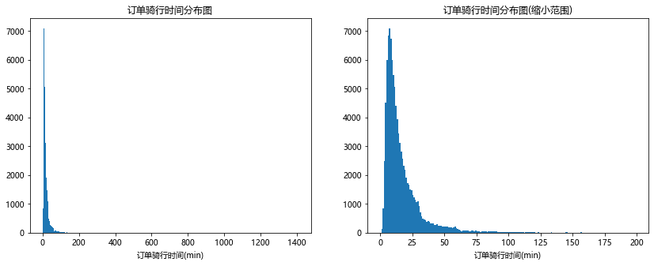

```python
# 拷贝数据
df_total_time = mobike_user_order.copy()

fig, ax = plt.subplots(ncols = 2, nrows = 1, figsize = [14, 5])

plt.sca(ax[0])
bins = np.arange(0, df_total_time.total_time.max()+1, 1)
plt.hist(data=df_total_time, x='total_time',bins=bins)
plt.xlabel('订单骑行时间(min)')
plt.title('订单骑行时间分布图')

plt.sca(ax[1])
bins = np.arange(0, 200, 1)
plt.hist(data=df_total_time, x='total_time',bins=bins)
plt.xlabel('订单骑行时间(min)')
plt.title('订单骑行时间分布图(缩小范围)')
```

观察到x轴的数据范围异常大（连续骑行1400分钟以上显然是不正常的），判断数据集中存在异常数据，可能是用户骑行后忘关锁造成的。其他异常情况还包括使用在投放单车过程中，汽车运载开锁后的摩拜单车的情况。

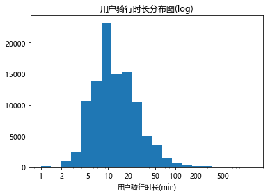

```python
bins = 10 ** np.arange(0, np.log10(df_total_time.total_time.max()) + 0.15, 0.15)
plt.hist(data = df_total_time, x = 'total_time', bins = bins);
plt.xscale('log')
xticks = (1, 2, 5, 10, 20, 50, 100, 200, 500)
plt.xticks(xticks, xticks);
plt.xlabel('用户骑行时长(min)');
plt.title('用户骑行时长分布图(log)');
```

骑行时长数据呈现长尾分布，绝大多数骑行时长较短，极少数骑行时间较长。使用log转换x轴绘图可以发现，骑行时长呈现右偏态分布，峰值出现在7-10分钟之间

### 骑行速度分析

考虑到数据的异常情况，剔除一下满足以下情况的数据,然后再重新绘制直方图观察骑行时长的数据分布情况;

- 剔除同时满足骑行速度明显异常（骑行速度一般在12-20km/h）、骑行时长（骑行时长大于400）
- 或骑行距离明显异常的记录（骑行距离小于100米）

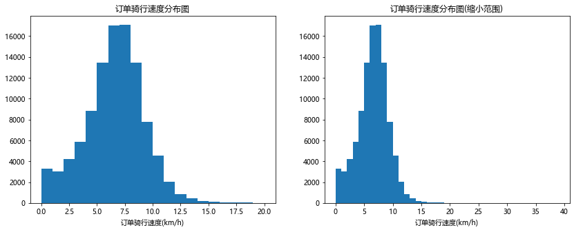

```python
# 剔除异常数据
df_total_time = df_total_time[(((df_total_time.speed>=0) & (df_total_time.speed<=20)) & ((df_total_time.total_time <= 400) | (df_total_time.distance>100)) )]

# 画图
fig, ax = plt.subplots(ncols = 2, nrows = 1, figsize = [14, 5])

plt.sca(ax[0])
bins = np.arange(0, df_total_time.speed.max()+1, 1)
plt.hist(data=df_total_time, x='speed',bins=bins )
plt.xlabel('订单骑行速度(km/h)')
plt.title('订单骑行速度分布图')

plt.sca(ax[1])
bins = np.arange(0, 40, 1)
plt.hist(data=df_total_time, x='speed',bins=bins )
plt.xlabel('订单骑行速度(km/h)')
plt.title('订单骑行速度分布图(缩小范围)')
```

```python
df_total_time[df_total_time['speed']<=2][['orderid','total_time','distance','speed']].head()
# df_total_time.distance.value_counts()
```

|  | orderid | total_time | distance | speed |
| --- | --- | --- | --- | --- |
| 29 | 1495443 | 20 | 488 | 1.464000 |
| 51 | 895784 | 79 | 702 | 0.533165 |
| 54 | 894093 | 15 | 347 | 1.388000 |
| 65 | 270836 | 262 | 2215 | 0.507252 |
| 78 | 1585735 | 25 | 581 | 1.394400 |

```python
df_total_time[df_total_time.orderid=='411943'][['orderid','total_time','distance','speed']]
```

|  | orderid | total_time | distance | speed |
| --- | --- | --- | --- | --- |
| 26 | 411943 | 30 | 1202 | 2.404 |

在剔除异常之后，骑行速度基本上集中分布在5-10km/h附近，极少数骑行速度在15km/h以上的； 对于骑行部分骑行速度小于2km/h的数据进行针对性分析，导致此原因可能有两；

- 一是在计算时直接使用了起始点计算骑行距离，导致部分用户计算值骑行距离小于实际骑行距离，引起骑行速度的偏小
- 二是在计算时使用坐标值进行计算，未能控制好精度或计算方法不够完善，导致计算值小于实际值，引起骑行速度的偏小

### 骑行距离分析

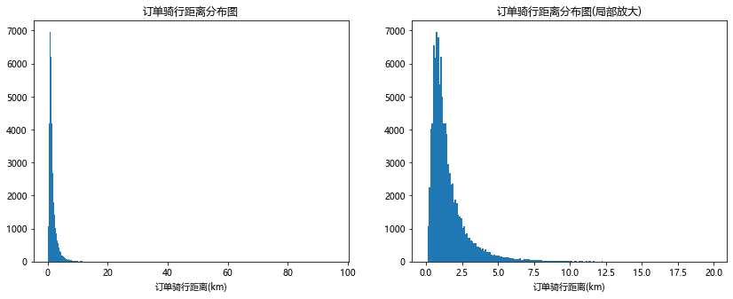

```python
# 增加 df_total_time 字段，将骑行距离单位从米转化为千米
df_total_time['distance_km'] = df_total_time.apply(lambda x: (x['distance']/1000), axis=1)

fig,ax = plt.subplots(nrows=1,ncols=2, figsize=[14,5])

plt.sca(ax[0])
bins = np.arange(0, (df_total_time.distance_km.max())+0.1, 0.1)
plt.hist(data=df_total_time, x='distance_km',bins=bins )
plt.xlabel('订单骑行距离(km)')
plt.title('订单骑行距离分布图')

plt.sca(ax[1])
bins = np.arange(0, 20, 0.1)
plt.hist(data=df_total_time, x='distance_km',bins=bins )
plt.xlabel('订单骑行距离(km)')
plt.title('订单骑行距离分布图(局部放大)')
```

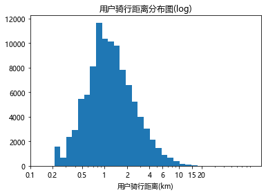

```python
# 对骑行距离进行log化
bins = 10 ** np.arange(np.log10(df_total_time.distance_km.min()), np.log10(df_total_time.distance_km.max()) + 0.01, 0.08)
plt.hist(data = df_total_time, x = 'distance_km', bins = bins);
plt.xscale('log')
xticks = (0.1, 0.2, 0.5, 1, 2, 4, 6, 10, 15, 20)
plt.xticks(xticks, xticks);
plt.xlabel('用户骑行距离(km)');
plt.title('用户骑行距离分布图(log)');
```

订单骑行距离同骑行距离一样，明显呈现长尾分布，绝大部分订单骑行距离集中在 0-2.5km区间内，极少数骑行距离较长，还存在异常值（如骑行距离达100km）；使用log转换X轴绘图可以发现，骑行距离呈现右偏分布，峰值出现在 0.7-2km之间；

### 订单24小时分布情况分析

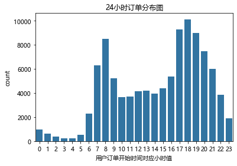

```python
color = sb.color_palette()[0]
sb.countplot(data=df_total_time, x='hour', color=color)
plt.xlabel('用户订单开始时间对应小时值')
plt.title('24小时订单分布图')
```

从24小时订单分布图中，数据呈现双峰分布，23-6点大家处于休息时间订单量较少；7-10点、17-20点处于上下班高峰期，订单量迅速增加；在12-13点间有小幅增加，应该是午餐时间，大家选择骑行去就餐，使得订单量增长；

### isweekend、ispeak、ring_stage、rate分类变量分析

订单时间相关的数据（isweekend、ispeak 等）与骑行时长相关性较高（如高峰时段骑行时长可能较短） 其他如地理位置（ring_stage）、用户质量（rate）等数据可能也会影响骑行时长

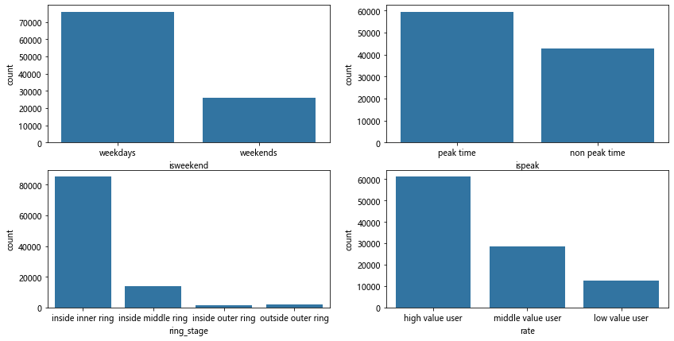

```python
fig, ax=plt.subplots(nrows=2,ncols=2, figsize=[14,7])
color = sb.color_palette()[0]

sb.countplot(data=df_total_time, x='isweekend', color=color, ax=ax[0,0])
sb.countplot(data=df_total_time, x='ispeak', color=color, ax=ax[0,1])
sb.countplot(data=df_total_time, x='ring_stage', color=color, ax=ax[1,0])
sb.countplot(data=df_total_time, x='rate', color=color, ax=ax[1,1])
```

### 变量分布情况与异常点或异常值处理

**变量分布情况**

**在数据探索中发现的异常分布情况，以及对此做出的清理、调整、格式转化等操作和原因**

在初次探索骑行时长和骑行距离的数据分布情况时，数值范围的最大值明显异常，通过剔除骑行速度、距离、时长的异常记录，提升数据集的数据质量，以便进一步操作

## 双变量分析

### 骑行时长与骑行距离关系分析

骑行时长与骑行距离最大值较大，且为长尾分布，为了更好的进一步分析，将骑行时长和骑行距离进行log转换,新增log_total_time、log_distance 两列。

```
                log_total_time  log_distance
log_total_time        1.000000      0.634696
log_distance          0.634696      1.000000
```

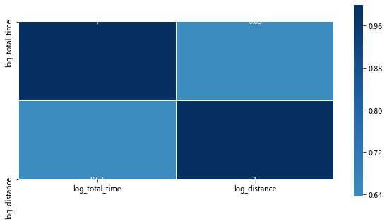

```python
# 定义数值变量与分类变量集
num_vars = ['log_total_time', 'log_distance']
cat_vars = ['isweekend', 'ispeak', 'ring_stage', 'rate']


# 将骑行时长与骑行距离log化
df_total_time['log_total_time'] = np.log10(df_total_time['total_time'])
df_total_time['log_distance'] = np.log10(df_total_time['distance_km'])


plt.figure(figsize=[10,5])
# sb.heatmap(df_total_time[num_vars].corr(), square=True, annot = True, fmt = '.3f', cmap = 'vlag_r', center = 0, linewidths=0.1);
sb.heatmap(df_total_time[num_vars].corr(), square=True, annot = True,  cmap = 'RdBu', center = 0, linewidths=0.1);
print(df_total_time[num_vars].corr())
```

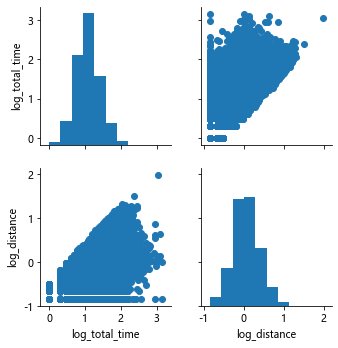

```python
# 在对角线上显示单变量分布：
g = sb.PairGrid(df_total_time[num_vars])
g.map_diag(plt.hist)
g.map_offdiag(plt.scatter)
```

骑行时长和骑行距离在经过log转换后，两者相关系数为0.635，为强相关关系

### 骑行时长和骑行距离与isweekend、ispeak、ring_stage、rate分类变量的关系分析（箱线图）

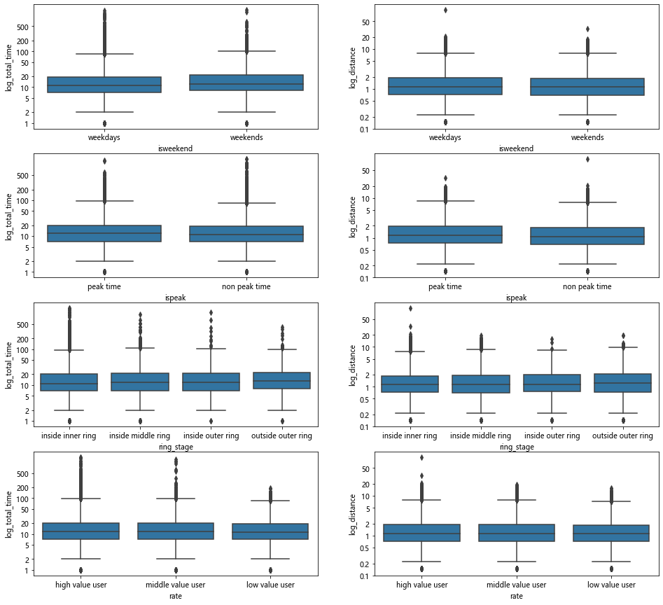

```python
fig, ax = plt.subplots(ncols=2, nrows=4,figsize=[16,15])
color = sb.color_palette()[0]

for i in range(len(cat_vars)):
    var = cat_vars[i]
    # 画骑行时长与分类变量关系图
    sb.boxplot(data=df_total_time, x=var, y='log_total_time', ax=ax[i,0], color=color)
    # 设置y轴坐标值与标签值
    total_time_ticks = (1, 2, 5, 10, 20, 50, 100, 200, 500)
    ax[i, 0].set_yticks(np.log10(total_time_ticks));
    ax[i, 0].set_yticklabels(total_time_ticks);

    # 画骑行距离与分类变量关系图
    sb.boxplot(data=df_total_time, x=var, y='log_distance', ax=ax[i,1], color=color)
    # 设置y轴坐标值与标签值
    log_distance_ticks = (0.1, 0.2, 0.5, 1, 2, 5, 10, 20, 50)
    ax[i, 1].set_yticks(np.log10(log_distance_ticks));
    ax[i, 1].set_yticklabels(log_distance_ticks);
```

- 在骑行时间方面；发现非工作日和高峰时段的骑行时长和骑行距离的中位数较工作日和非高峰时段要高（其中非工作日的骑行距离较工作日低，考虑到在计算骑行距离时只使用了起始点进行计算，忽略了实际骑行中的中间距离，可能导致周末骑行时起始点可能在附近，但实际骑行距离远大于起始点距离，因此该值应该是计算导致的误差，后期可以改进计算用户骑行距离的方法）
- 在骑行区域方面，骑行时长和骑行距离的中位数，均随着离市中心越远而变得越高，其原因是郊区附近公共交通工具没有市内丰富，出行时出发点和目的地的距离变大，导致骑行时长和骑行距离的增加；
- 在用户价值方面，骑行时长和骑行距离的中位数随着用户价值的变低而减小；

### 骑行时长和骑行距离与isweekend、ispeak、ring_stage、rate分类变量的关系分析（小提琴图）

因为在箱线图中，骑行时长和骑行距离两个数值变量的数据特征变化特征相似，为了更好的从数据分布上查看分布情况，使用小提琴图查看具体的数据分布情况；

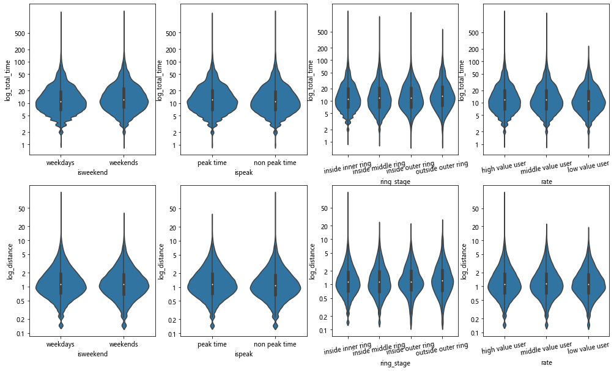

```python
fig, ax = plt.subplots(ncols=4, nrows=2,figsize=[17,10])
color = sb.color_palette()[0]

for i in range(len(cat_vars)):
    var = cat_vars[i]
    # 画骑行时长与分类变量关系图
    sb.violinplot(data=df_total_time, x=var, y='log_total_time', ax=ax[0,i], color=color)
    # 设置y轴坐标值与标签值
    total_time_ticks = (1, 2, 5, 10, 20, 50, 100, 200, 500)
    ax[0,i].set_yticks(np.log10(total_time_ticks));
    ax[0,i].set_yticklabels(total_time_ticks);
    # 为了x轴过长的正常显示进行小幅旋转
    if i >= 2:
        xlabels = ax[0,i].get_xticklabels()
        ax[0,i].set_xticklabels(xlabels, rotation=10)

    # 画骑行距离与分类变量关系图
    sb.violinplot(data=df_total_time, x=var, y='log_distance', ax=ax[1,i], color=color)
    # 设置y轴坐标值与标签值
    log_distance_ticks = (0.1, 0.2, 0.5, 1, 2, 5, 10, 20, 50)
    ax[1,i].set_yticks(np.log10(log_distance_ticks));
    ax[1,i].set_yticklabels(log_distance_ticks);
    if i >= 2:
        xlabels = ax[1,i].get_xticklabels()
        ax[1,i].set_xticklabels(xlabels, rotation=10)
```

通过小提琴图和箱线图可以发现，骑行时长和骑行距离这两个数值变量的数据分布特征和分类情况下的变化特征几乎完全一样，后续可以不再对骑行距离做分析，原因如下：一方面骑行时长是原始数据中的真实数据（骑行距离是通过骑行始末点估算的直线距离，与实际情况可能偏离更大），另一方面摩拜单车是根据骑行时长作为付费依据的，故此，在较高相关性和相似数据特征的情况下，选择数据质量和价值更高的骑行时长作为后续分析指标

### isweekend、ispeak、ring_stage、rate各分类变量间的关系（分组条形图）

使用分组条形图，分析四个分类变量间的关系

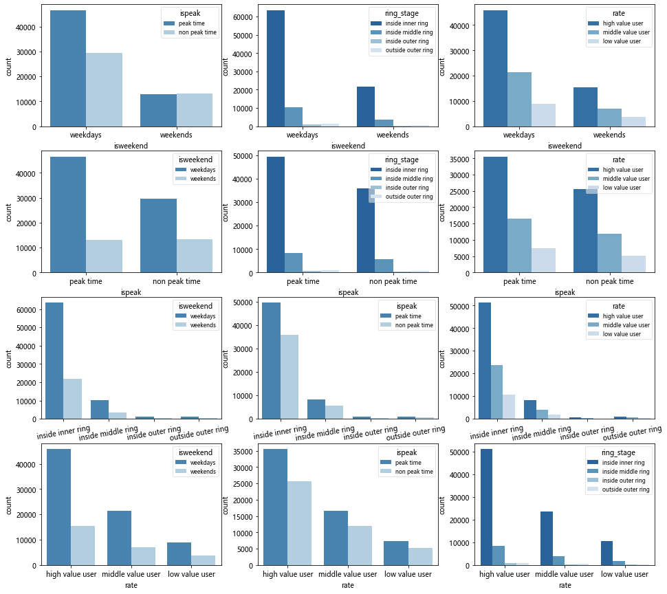

```python
fig,ax = plt.subplots(ncols=3, nrows=4, figsize=[16,15])


for i in range(len(cat_vars)):
    count = 0
    for j in range(len(cat_vars)):
        if j==i:
            continue;
        else:
            sb.countplot(data=df_total_time, x=cat_vars[i], hue=cat_vars[j], palette = 'Blues_r', ax=ax[i,count])
            ax[i, count].legend(title = cat_vars[j], fontsize = 8, framealpha = 0.5);
            if i==2:
                xlabels = ax[i,count].get_xticklabels()
                ax[i,count].set_xticklabels(xlabels, rotation=10)
            count+=1
```

## 多变量探索分析

主要探索isweekend、ispeak、ring_stage、rate四个分类变量是如何影响骑行时长的;

- 分析在工作日/非工作日或高峰期/非高峰期情况时，在不同区域的用户的不同价值用户的骑行时长分布图
- 分析在不同价值用户情况下，在不同区域的用户，在工作日/非工作日或高峰期/非高峰期时的骑时长分布图
- 分析在不同区域或不同价值用户的情况下，在高峰期/非高峰期时用户，在工作日/非工作日骑行时长分布图

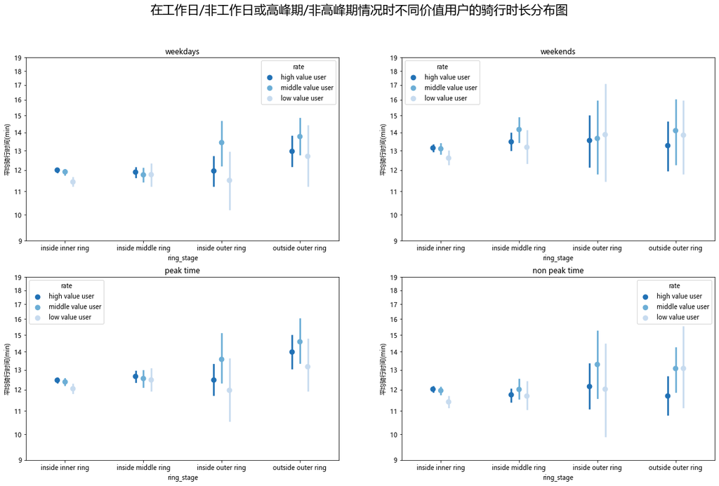

```python
# 在工作日/非工作日或高峰期/非高峰期情况时，在不同区域的用户的不同价值用户的骑行时长分布图
fig = plt.figure(figsize = [20, 12])
row_dict = {'221': {'flag': 'weekdays', 'hue': 'rate'},
            '222': {'flag': 'weekends', 'hue': 'rate'},
            '223': {'flag': 'peak time', 'hue': 'rate'},
            '224': {'flag': 'non peak time', 'hue': 'rate'}}

for var in row_dict:
    plt.subplot(var)
    if var in ['221','222']:
        ax = sb.pointplot(data=df_total_time[(df_total_time.isweekend == row_dict[var]['flag'])],
                     x='ring_stage', y='log_total_time',  hue=row_dict[var]['hue'], palette='Blues_r', linestyles='', dodge=0.2)
    else:
        ax = sb.pointplot(data=df_total_time[(df_total_time.ispeak == row_dict[var]['flag'])],
                     x='ring_stage', y='log_total_time',  hue=row_dict[var]['hue'], palette='Blues_r', linestyles='', dodge=0.2)

    # 设置合适的y轴刻度
    total_time_ticks = [x for x in range(9,20,1)]
    plt.yticks(np.log10(total_time_ticks),total_time_ticks);


    # 设置标题
    plt.ylabel('平均骑行时间(min)')
    plt.title(row_dict[var]['flag'])
    # plt.title('在 {} 时不同价值用户平均骑行时长情况'.format(row_dict[var]['flag']))

fig.suptitle('在工作日/非工作日或高峰期/非高峰期情况时不同价值用户的骑行时长分布图', size=20)
```

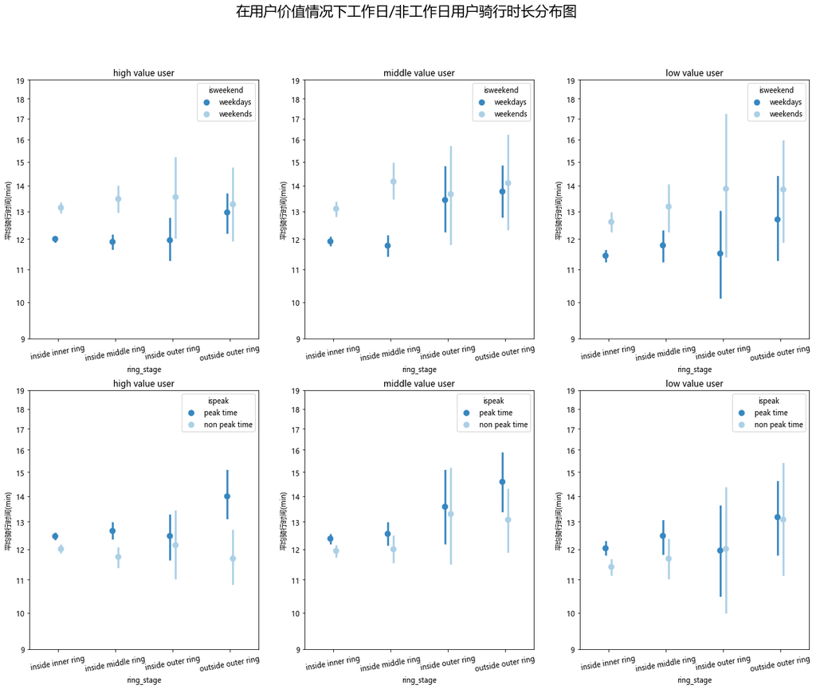

```python
# 在不同价值用户情况下，在不同区域的用户，在工作日/非工作日或高峰期/非高峰期时的骑时长分布图
fig = plt.figure(figsize = [20,15])
row_dict = {'231': {'flag': 'high value user', 'hue': 'isweekend'},
            '232': {'flag': 'middle value user', 'hue': 'isweekend'},
            '233': {'flag': 'low value user', 'hue': 'isweekend'},
            '234': {'flag': 'high value user', 'hue': 'ispeak'},
            '235': {'flag': 'middle value user', 'hue': 'ispeak'},
            '236': {'flag': 'low value user', 'hue': 'ispeak'} }

for var in row_dict:
    plt.subplot(var)
    if var in ('231','232','233'):
        sb.pointplot(data=df_total_time[(df_total_time.rate == row_dict[var]['flag'])],
                     x='ring_stage', y='log_total_time',  hue=row_dict[var]['hue'], palette='Blues_r', linestyles='', dodge=0.1)
        # plt.title('{} 价值用户在工作与非工作日的平均骑行时长'.format(row_dict[var]['flag']))
    else:
        sb.pointplot(data=df_total_time[(df_total_time.rate == row_dict[var]['flag'])],
                     x='ring_stage', y='log_total_time',  hue=row_dict[var]['hue'], palette='Blues_r', linestyles='', dodge=0.1)
        # plt.title('{} 价值用户在高峰期与非高峰期的平均骑行时长'.format(row_dict[var]['flag']))

    # 设置合适的y轴刻度
    total_time_ticks = [x for x in range(9,20,1)]
    plt.yticks(np.log10(total_time_ticks),total_time_ticks);
    plt.xticks(rotation=10)
    # 设置标题
    plt.ylabel('平均骑行时间(min)')
    plt.title(row_dict[var]['flag'])

fig.suptitle('在用户价值情况下工作日/非工作日用户骑行时长分布图', size=20)
```

- 从第一行可以看出：用户在工作日的平均骑行时长都要小于非工作日的平均骑行时长。这可能是因为在工作日时上下班时间比较赶，而非工作日时用户有很多的空闲时间；
- 从第二行可以看出：用户在高峰期的平均骑行时长均要大于非高峰期。在整体上看用户的平均骑行时长随着区域离市中心的距离增加而增加(除了内环区域的高价值用户，因为上班工作时间一般都在办公室中办公，长时间骑行的可能性非常小，导致此类数据较少)；

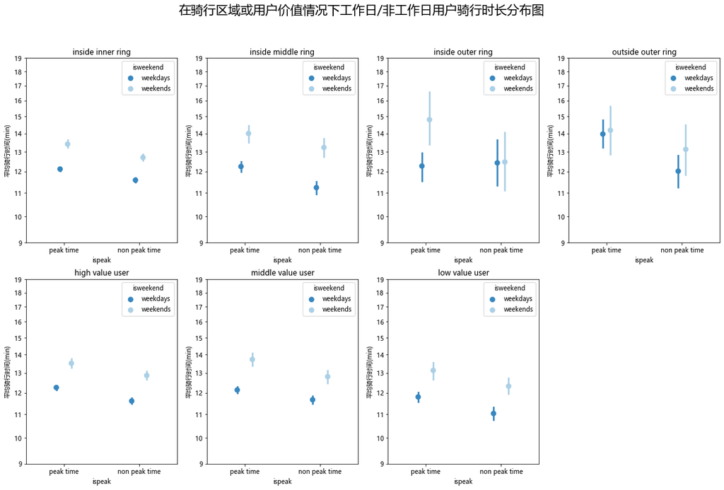

```python
# 在不同区域或不同价值用户的情况下，在高峰期/非高峰期时用户，在工作日/非工作日骑行时长分布图
fig = plt.figure(figsize = [20,12])
row_dict = {'241': {'flag': 'inside inner ring', 'hue': 'isweekend'},
            '242': {'flag': 'inside middle ring', 'hue': 'isweekend'},
            '243': {'flag': 'inside outer ring', 'hue': 'isweekend'},
            '244': {'flag': 'outside outer ring', 'hue': 'isweekend'},
            '245': {'flag': 'high value user', 'hue': 'isweekend'},
            '246': {'flag': 'middle value user', 'hue': 'isweekend'},
            '247': {'flag': 'low value user', 'hue': 'isweekend'}}


for var in row_dict:
    plt.subplot(var)
    if var in ['241','242','243','244']:
        sb.pointplot(data=df_total_time[(df_total_time.ring_stage == row_dict[var]['flag'])],
                     x='ispeak', y='log_total_time',  hue=row_dict[var]['hue'], palette='Blues_r', linestyles='', dodge=0.1)
        # plt.title('在 {} 区域在工作日与非工作日的平均骑行时长'.format(row_dict[var]['flag']), fontsize = 'small')
    else:
        sb.pointplot(data=df_total_time[(df_total_time.rate == row_dict[var]['flag'])],
                     x='ispeak', y='log_total_time',  hue=row_dict[var]['hue'], palette='Blues_r', linestyles='', dodge=0.2)
        # plt.title('{} 价值用户在工作日与非工作日的平均骑行时长'.format(row_dict[var]['flag']), fontsize = 'small')
    # 设置合适的y轴刻度
    total_time_ticks = [x for x in range(9,20,1)]
    plt.yticks(np.log10(total_time_ticks),total_time_ticks);
    # 设置标题
    plt.ylabel('平均骑行时间(min)')
    plt.title(row_dict[var]['flag'])

fig.suptitle('在骑行区域或用户价值情况下工作日/非工作日用户骑行时长分布图', size=20)
```

在分别限制用户骑行区域和用户价值的情况下,可以看到数据点的分布的相对位置高度相似：

- 说明高峰时段与否和是否工作日对于平均骑行时长的规律十分明显，即在骑行区域或用户价值相同的情况下，在高峰时段和非工作日的骑行时长都高于非高峰期和工工作日；
- 在第二行中以用户价值变量查看数据分布，可以发现随着用户价值由高到低，用户平均骑行时长变化幅度非常小，说明用户价值对于平均骑行时长的影响较小，远小于骑行区域对于平均骑行时长的影响；

## 变量之间有趣或意外的发现

比较不同骑行区域和用户价值类型下，工作日和高峰时段的数据点分布特征高度类似，说明工作日和高峰时段的用车行为特征相似

## 参考资料：

https://blog.csdn.net/sinat_35930259/article/details/80002213  
https://blog.csdn.net/weixin_42936350/article/details/104257417  
https://blog.csdn.net/brucewong0516/article/details/81782312?depth_1-utm_source=distribute.pc_relevant.none-task-blog-BlogCommendFromMachineLearnPai2-1&utm_source=distribute.pc_relevant.none-task-blog-BlogCommendFromMachineLearnPai2-1  
https://www.cntofu.com/book/172/docs/35.md  
https://lbs.amap.com/console/show/picker